# Sketches

Project rationale, goals, and target scenarios.

Taren Sanders https://github.com/tarensanders (IPPE, Australian Catholic University)https://www.acu.edu.au/research-and-enterprise/our-research-institutes/institute-for-positive-psychology-and-education  
2022-05-22

# Scenarios

There are two groups of users we think might want to access the system. Example use cases are given below.

## Scenario One

**Users:** Parents

> A parent wants to explore the types of exposure. The select a particular exposure (e.g., TV) might impact their child. They search for the exposure and are given an overview of the known outcome categories. Visualise info about the uncertainty for each effect. They filter the results for their child’s age. They click into an outcome category to get more information on the result (e.g., text summary, info about reason for the uncertainty).

# Scenario Two

**Users:** Researchers/clinicians

> A domain expert wants to explore evidence for screen time in more detail. Use the system to get an overview of the evidence (exposure, outcome, effect size). They search for the exposure and/or the outcome, and optionally filter by age. They click into a relationship and can access the forest plot of the original studies, and the link to the original meta-analysis (and other, related studies, uncertainty). Three levels: evidence, uncertainty, meta-data.

# Tasks/Screens

## Task One

> Explore the exposures that there are evidence for.

**Proposed Idiom:** Heatmap

### Counts

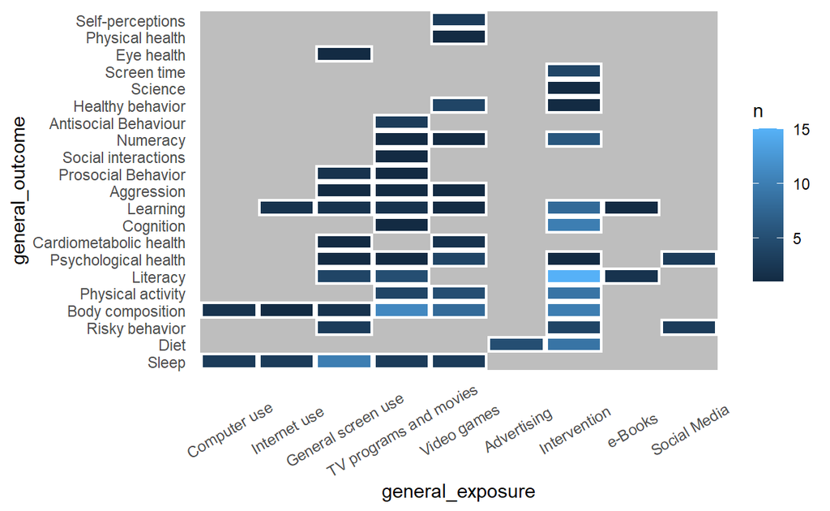

### Effect sizes

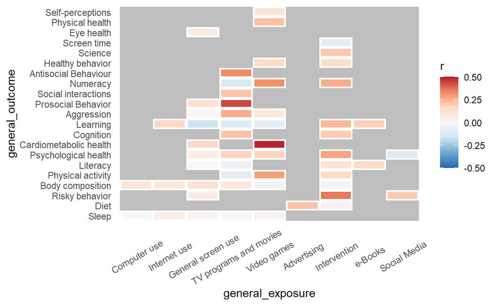

### Side-by-side

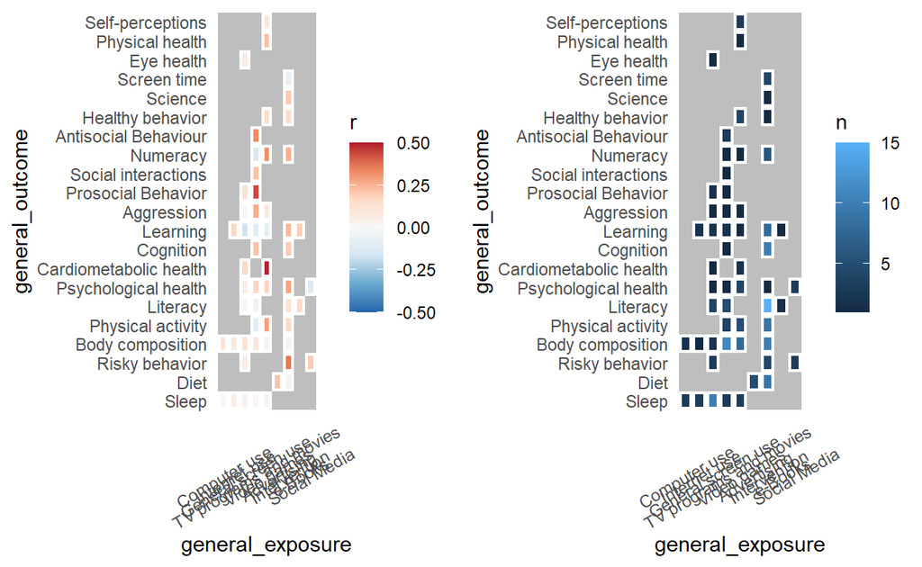

## Task Two

> Explore an overview of the outcome categories for the selected exposure category.

(*E.g., if they have chosen ‘video games’*)

### Option One (Heatmap)

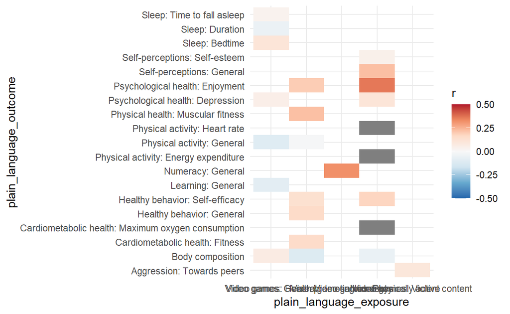

### Option Two (Line Range)

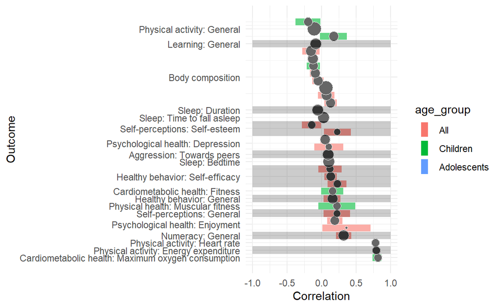

### Notes

- I think the heatmap is likely to be more intuitive
- We could instead put the line range in the tooltip or in the next screen
- The proposed interaction would be hover and click in for details
- Study quality could also be in the tooltip

## Task Three

> Show detailed information about the effect

*TODO* - I think this will likely be a formatted page with an interpretation, plus original forest plot and links to studies for ‘expert’ users.